# classification image by NN

NSABIMANA FRANCOIS

NORTHWESTERN POLYTECHNICAL UNIVERSITY

CLASSIFY CATS VS DOGS BY USING NEURAL NETWORK AS MODEL

DATE OF REPORT3:17TH JUNE 2020

SUPERVISOR:CAI LI

Last time i reviewed about neural network, how it works in few word. Now i am going also to classify the iamges of cats and dogs using Neural Network as our Model.Firstly, I can stard by saying this:

Neural Networks (NN), or more precisely Artificial Neural Networks (ANN), is a class of Machine Learning algorithms that recently received a lot of attention (again!) due to the availability of Big Data and fast computing facilities (most of Deep Learning algorithms are essentially different variations of ANN).

The class of ANN covers several architectures including Convolutional Neural Networks (CNN), Recurrent Neural Networks (RNN) eg LSTM and GRU, Autoencoders, and Deep Belief Networks. Therefore, CNN is just one kind of ANN

Generally speaking, an ANN is a collection of connected and tunable units (a.k.a. nodes, neurons, and artificial neurons) which can pass a signal (usually a real-valued number) from a unit to another. The number of (layers of) units, their types, and the way they are connected to each other is called the network architecture.

A CNN, in specific, has one or more layers of convolution units. A convolution unit receives its input from multiple units from the previous layer which together create a proximity. Therefore, the input units (that form a small neighborhood) share their weights.

The convolution units (as well as pooling units) are especially beneficial as:

They reduce the number of units in the network (since they are many-to-one mappings). This means, there are fewer parameters to learn which reduces the chance of overfitting as the model would be less complex than a fully connected network. They consider the context/shared information in the small neighborhoods. This future is very important in many applications such as image, video, text, and speech processing/mining as the neighboring inputs (eg pixels, frames, words, etc) usually carry related information.

# To build our image classifier, we begin by downloading the dataset. The dataset we are using is a filtered version of Dogs vs. Cats dataset from Kaggle (ultimately, this dataset is provided by Microsoft Research).

# In this colabs, i am using tensorflow ,which is easy to implement deep learning models that operate over data of varying size and structure.

```python
import cv2  # working with mainly resizing images
import numpy as np # dealing with arrays
import os  # dealing with directories
from random import shuffle #  mixing up or currently ordered data that might lead our network astray in training.
from tqdm import tqdm # a nice pretty percentage bar for tasks

import tensorflow as tf
import tflearn
from tflearn.layers.conv import conv_2d, max_pool_2d
from tflearn.layers.core import input_data, dropout, fully_connected
from tflearn.layers.estimator import regression

import matplotlib.pyplot as plt
```

[output not shown]

```python
TRAIN_DIR = 'D:/train'
TEST_DIR = 'D:/test'
IMG_SIZE = 50
LR = 1e-3

# Just so we remember which saved model is which sizes must match
MODEL_NAME = 'dogsvscats-{}-{}.model'.format(LR, '2conv-basic')
```

Now, our fist order of task is to convert the images and labels to array information that we can pass through our network.A part of this, we will need a helper function to convert the image name to array.

Our images are labeled like "cat.1" or "dog.3" etc,therefore, we can just split out the dog/cat and then convert to array like so:

```python
def label_img(img):
    word_label = img.split('.')[-3]
    # conversion to one-hot array [cat,dog]
    #                            [much cat, no dog]
    if word_label == 'cat': return [1,0]
    #                             [no cat, very doggo]
    elif word_label == 'dog': return [0,1]
```

Thus, we can build another function to fully process the training images and their labels into arrays. # About this , it is good way to use the tqdm module, i am rolling to use it because it is a really nice pretty way to measure where we are in a process,rather than printing things out at intervals and it is gives a progress bar(super neat) # when we have gone through all of the images, we shuffle them, then save. shuffle modifies a variables in place. #with this function, we will both save , and return the array data. This way, if we just change the neural network's structure and no something with the images, like image size ...then we can just load the array file and save some process the testing data.

```python
def create_train_data():
    training_data = []
    for img in tqdm(os.listdir(TRAIN_DIR)):
        label = label_img(img)
        path = os.path.join(TRAIN_DIR,img)
        img = cv2.imread(path,cv2.IMREAD_GRAYSCALE)
        img = cv2.resize(img, (IMG_SIZE,IMG_SIZE))
        training_data.append([np.array(img),np.array(label)])
    shuffle(training_data)
    np.save('train_data.npy', training_data)
    return training_data
```

```python
def process_test_data():
    testing_data = []
    for img in tqdm(os.listdir(TEST_DIR)):
        path = os.path.join(TEST_DIR,img)
        img_num = img.split('.')[0]
        img = cv2.imread(path,cv2.IMREAD_GRAYSCALE)
        img = cv2.resize(img, (IMG_SIZE,IMG_SIZE))
        testing_data.append([np.array(img), img_num])

    shuffle(testing_data)
    np.save('test_data.npy', testing_data)
    return testing_data
```

Now, we can run the training:

```python
# if we have already created the dataset: then
# train_data = np.load('train_data.npy')
train_data = create_train_data()
```

```python
convnet = input_data(shape=[None, IMG_SIZE, IMG_SIZE, 1], name='input')

convnet = conv_2d(convnet, 32, 5, activation='relu')
convnet = max_pool_2d(convnet, 5)

convnet = conv_2d(convnet, 64, 5, activation='relu')
convnet = max_pool_2d(convnet, 5)

convnet = fully_connected(convnet, 1024, activation='relu')
convnet = dropout(convnet, 0.8)

convnet = fully_connected(convnet, 2, activation='softmax')
convnet = regression(convnet, optimizer='adam', learning_rate=LR, loss='categorical_crossentropy', name='targets' )


model = tflearn.DNN(convnet, tensorboard_dir='log')
```

[output not shown]

Above, we have 2 layers convolutional neural network , with a fully connected layer and the output layer.On other hand, it is been choiced whether or not a fully connected layer is of any use.

secondly, to modify our model , just we can add the layer or remove it.

Then Now, we just want to see how epochstrains used, may be 3 or 5 epochs etc . We want tobe saving our model after every session and reloading it.

```python
if os.path.exists('{}.meta'.format(MODEL_NAME)):
    model.load(MODEL_NAME)
    print('model loaded')
```

```
INFO:tensorflow:Restoring parameters from C:\Users\FRANCIS\dogsvscats-0.001-2conv-basic.model
model loaded
```

```python
#we are going to split out training and testing dara:

train = train_data[:-500]
test = train_data[-500:]
```

now ,the training dataand testing data both are labeled datasets.

The training data is what we will fit the neural network while test data will be out of sample(the testing data will only be used to test the accuracy of the network , not to train it.

Next, we are going to create our data arrays. that is why we are taking numpy so:

```python
X = np.array([i[0] for i in train]).reshape(-1,IMG_SIZE,IMG_SIZE,1)
Y = [i[1] for i in train]

test_x = np.array([i[0] for i in test]).reshape(-1,IMG_SIZE,IMG_SIZE,1)
test_y = [i[1] for i in test]
```

```python
model.fit({'input': X}, {'targets': Y}, n_epoch=3, validation_set=({'input': test_x}, {'targets': test_y}),
    snapshot_step=500, show_metric=True, run_id=MODEL_NAME)
```

```
Training Step: 4978  | total loss: 0.33605 | time: 69.894s
| Adam | epoch: 013 | loss: 0.33605 - acc: 0.8579 -- iter: 24448/24500
Training Step: 4979  | total loss: 0.33692 | time: 71.080s
| Adam | epoch: 013 | loss: 0.33692 - acc: 0.8565 | val_loss: 0.65717 - val_acc: 0.7420 -- iter: 24500/24500
--
```

# Size Matters

Up here, we need a bigger network and need to reset the graph instance,and we are going to add some layers and using a big epoch,so let's go:

```python
import tensorflow as tf
tf.reset_default_graph()
```

```python
convnet = input_data(shape=[None, IMG_SIZE, IMG_SIZE, 1], name='input')

convnet = conv_2d(convnet, 32, 5, activation='relu')
convnet = max_pool_2d(convnet, 5)

convnet = conv_2d(convnet, 64, 5, activation='relu')
convnet = max_pool_2d(convnet, 5)

convnet = conv_2d(convnet, 128, 5, activation='relu')
convnet = max_pool_2d(convnet, 5)

convnet = conv_2d(convnet, 64, 5, activation='relu')
convnet = max_pool_2d(convnet, 5)

convnet = conv_2d(convnet, 32, 5, activation='relu')
convnet = max_pool_2d(convnet, 5)

convnet = fully_connected(convnet, 1024, activation='relu')
convnet = dropout(convnet, 0.8)

convnet = fully_connected(convnet, 2, activation='softmax')
convnet = regression(convnet, optimizer='adam', learning_rate=LR, loss='categorical_crossentropy', name='targets')

model = tflearn.DNN(convnet, tensorboard_dir='log')
```

```python
if os.path.exists('C:/Users/H/Desktop/KaggleDogsvsCats/{}.meta'.format(MODEL_NAME)):
    model.load(MODEL_NAME)
    print('model loaded!')
```

```python
train = train_data[:-500]
test = train_data[-500:]
```

```python
X = np.array([i[0] for i in train]).reshape(-1,IMG_SIZE,IMG_SIZE,1)
Y = [i[1] for i in train]

test_x = np.array([i[0] for i in test]).reshape(-1,IMG_SIZE,IMG_SIZE,1)
test_y = [i[1] for i in test]

model.fit({'input': X}, {'targets': Y}, n_epoch=10, validation_set=({'input': test_x}, {'targets': test_y}),
    snapshot_step=500, show_metric=True, run_id=MODEL_NAME)

model.save(MODEL_NAME)
```

```
Training Step: 3829  | total loss: 0.36647 | time: 78.078s
| Adam | epoch: 010 | loss: 0.36647 - acc: 0.8277 -- iter: 24448/24500
Training Step: 3830  | total loss: 0.35977 | time: 79.307s
| Adam | epoch: 010 | loss: 0.35977 - acc: 0.8324 | val_loss: 0.48293 - val_acc: 0.7680 -- iter: 24500/24500
--
INFO:tensorflow:C:\Users\FRANCIS\dogsvscats-0.001-2conv-basic.model is not in all_model_checkpoint_paths. Manually adding it.
```

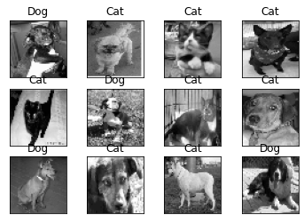

```python
# if you need to create the data:
#test_data = process_test_data()
# if you already have some saved:
test_data = np.load('test_data.npy')

fig=plt.figure()

for num,data in enumerate(test_data[:12]):
    # cat: [1,0]
    # dog: [0,1]

    img_num = data[1]
    img_data = data[0]

    y = fig.add_subplot(3,4,num+1)
    orig = img_data
    data = img_data.reshape(IMG_SIZE,IMG_SIZE,1)
    #model_out = model.predict([data])[0]
    model_out = model.predict([data])[0]

    if np.argmax(model_out) == 1: str_label='Dog'
    else: str_label='Cat'

    y.imshow(orig,cmap='gray')
    plt.title(str_label)
    y.axes.get_xaxis().set_visible(False)
    y.axes.get_yaxis().set_visible(False)
plt.show()
```

```python
with open('submission-file.csv','w') as f:
    f.write('id,label\n')
```

```python
with open('submission_file.csv','w') as f:
    f.write('id,label\n')

with open('submission_file.csv','a') as f:
    for data in tqdm(test_data):
        img_num = data[1]
        img_data = data[0]
        orig = img_data
        data = img_data.reshape(IMG_SIZE,IMG_SIZE,1)
        model_out = model.predict([data])[0]
        f.write('{},{}\n'.format(img_num,model_out[1]))
```

Thank you!